# Lab 1: Linear regression

Erik Gahner Larsen

Advanced applied statistics, 2015

# Everything you need to know about me (in 30 seconds or less)

- Erik
- Interest(s): Design-based causal inference, experiments
- Mail: erikgahner@gmail.com / egl@sam.sdu.dk

# Goal of lab sessions

- Work with STATA/R
- Learn to do awesome **and** useful stuff
  - Relevant for mandatory assignments, the exam, thesis, work etc.
- You will get the code (as R scripts and STATA do-files)
  - Your job is to make it your own (understand the code, add interpretations and stuff)

# Today

- Having fun with statistics, or: Work with tasks
  - Calculate standard errors and confidence intervals
  - Test for mean differences (t-test)
  - Linear regression (simple and multiple)
  - Interaction terms
- If you can do this: The first mandatory assignment will be a walk in the park.

# Mandatory assignment: Linear regression

- You can write it in Danish or English (we recommend the latter option)
- If you think it is too easy, use it as an opportunity to try R (or STATA)
- Important dates
  - Hand-out date: Today
  - Due date: 16 September (Wednesday)
  - Feedback: 23 September (Wednesday)
  - Resubmission: 30 September (Wednesday)

# On differences in statistical significance

- “The difference between significant and not significant is not itself statistically significant”
- “Statistical significance, in some form, is a way to assess the reliability of statistical findings. However, as we have seen, comparisons of the sort,”X is statistically significant but Y is not," can be misleading."
- Source: Gelman, A. and H. Stern. 2006. The Difference Between “Significant” and “Not Significant” is not Itself Statistically Significant. *The American Statistician*. 60(4), 328-331

# If in doubt, draw it out.

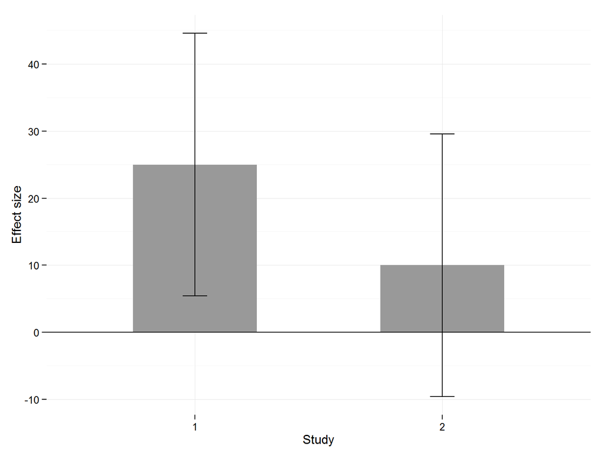

# Any problems?

- Do you have an installation of STATA and R?
- Any feedback?
  - Lectures?
  - Literature?
  - A waste of time?

# Now

- Go to BlackBoard
- Download files for `lab 1`
- Work with the tasks
- If you need help, ask.
- Work in groups or alone

# Task 1

Between country differences in average political knowledge

```
a) Compare the country (group) means of political knowledge scores to each-other.

b) Construct and interpret confidence intervals for the grand mean as well as
for each of the group means.

c) Conduct and interpret a t-test of the difference in group means.
```

# Task 2

Next, investigate the relationship between religiosity (predictor) and leftright ideological self-placement using simple linear regression. Use either the Danish or the Polish sample.

```
a) Start by illustrating the relationship between these two.

b) Next, interpret the point and interval estimates for the intercept and
slope from a bivariate regression.

c) Finally, interpret the standardized coefficient for religiosity.
```

# Task 3

It is now time to add additional covariates to our model: age, education, gender, and investigate whether this affects the relationship between religiosity and ideological self-placement.

```
a) Start by discussing why we want to add these additional variables to our model.

b) Investigate this multivariate relationship using multiple linear regression.

c) Display the relationship between religiosity and ideological positions based
on your multivariate model, fixing other predictors to meaningful values.
Try out at least two different set of "hypothetical individuals".
```

# Task 4

Finally, investigate whether the effect of religiosity on ideological placement is conditional on age.

```
a) Estimate a multiple linear regression which allows for this conditionality.

b) Illustrate the conditionality.
```

# Mandatory assignment

```
1. Examine the bivariate and multivariate relationship between gender
(female) and political knowledge (polinfo, y ) in Poland. At a minimum,
consider the following third variables: age, education, political interest.

2. Investigate also possible parameter heterogeneity in the relationship
between gender and political knowledge (using interactions).

3. Illustrate graphically the key results from your analysis, especially
where you find indications of heterogeneity in the gender gap.

4. Export your empirical results using an appropriate command (Stata:
e.g., outreg2; R: e.g., texreg). Report the results from your regressions
in a single table. The table's format and content must conform to the
usual standards for such tables.
```

# A few words of advice

- Make your shit reproducible
  - Irreproducible science is an oxymoron
  - If nobody can reproduce your results, **you** are doing something wrong.
- Do not conduct a misleading interaction analysis
  - Plot and discuss the distribution of the variables (e.g. histograms)
  - Plot and discuss the uncertainty in your estimates (e.g. 95% confidence intervals)
  - Remember substantial interpretation

# Good luck with the assignment

- Feel free to stop by my office